# Homework 10 - [YOUR NAME HERE]

## **Problem 1.e. (1 pt)**

Using the R chunk below with the nrc lexicon and `news_headlines`, create a ggplot image that shows the top 10 words for following sentiments only: disgust and joy. Again, make sure to exclude stop words. Ensure that the disgust and joy words are split into two side-by-side panels (i.e., use `facet_wrap()` as taught in lecture). If desired, you may create additional R chunks below.

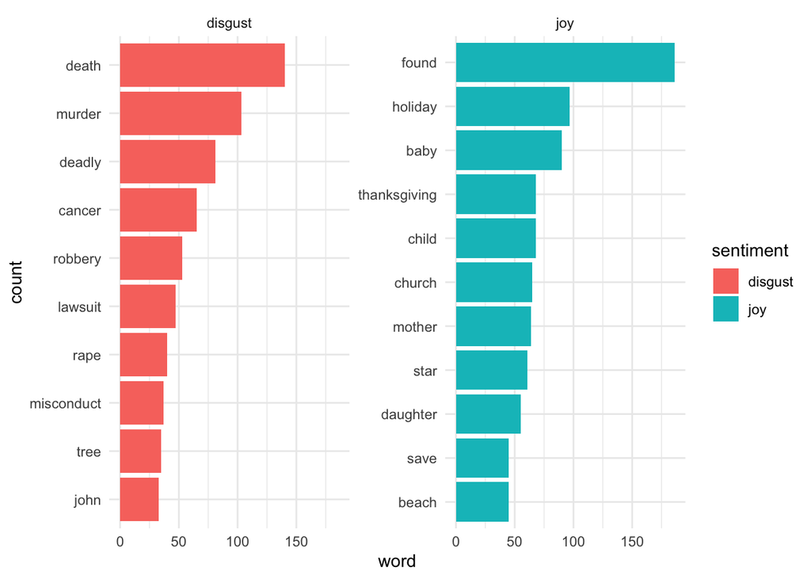

```r
# Place your code below
nrc_lexicon_filtered <- get_sentiments('nrc') |>
  filter(sentiment %in% c('disgust','joy'))

nrc_headlines_top_10 <- news_headlines_tidy |>
  anti_join(stop_words) |>
  inner_join(nrc_lexicon_filtered) |>
  group_by(sentiment,word) |>
  summarise(count=n()) |>
  group_by(sentiment) |>
  slice_max(count,n=10)
ggplot(data=nrc_headlines_top_10, mapping=aes(x=count,
                                              y=fct_reorder(word,count),
                                              fill=sentiment)) +
  geom_col() +
  facet_wrap(~sentiment, scales='free_y') +
  theme_minimal() +
  labs(x='word',
       y='count')
```

## **Problem 1.f. (1 pt)**

Using the R chunk below, create a word cloud for `news_headlines` using the using wordcloud package:

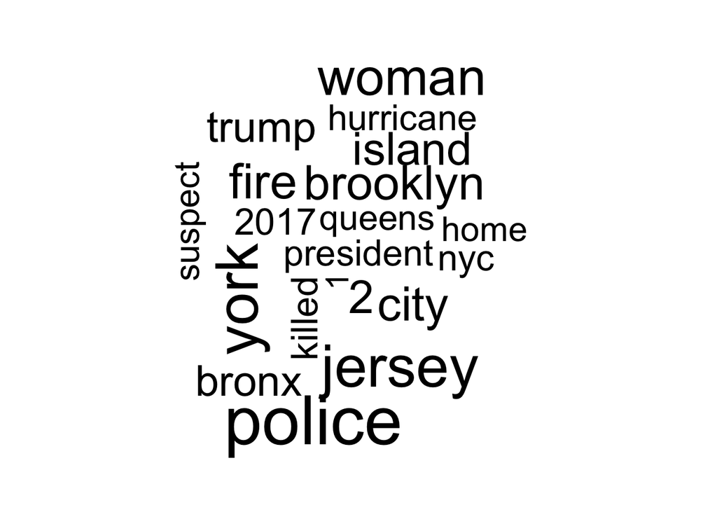

```r
# Place your code below
news_headlines_tally <- news_headlines_tidy |>
  anti_join(stop_words) |>
  group_by(word) |>
  summarize(count=n())
wordcloud(words = news_headlines_tally$word,
          freq = news_headlines_tally$count,
          max.words = 20) # any number is fine
```

## Problem 2 (1 pt)

**Note: This is Practice 3 from Lecture 10 that we didn’t have time to do in class.**

Your ultimate goal is to create the top 10 words visually for both negative and positive sentiment. After running the first R chunk, make sure to follow the prompts within the second R chunks.

```r
# Creates an R object called hgwells_data
# hgwells_data contains text data from the works of H.G. Wells' "The Time Machine"
library(gutenbergr)
hgwells_data <- gutenberg_download(c(35))
```

```
Determining mirror for Project Gutenberg from
https://www.gutenberg.org/robot/harvest.
Using mirror https://aleph.gutenberg.org.
```

Code you need to fill in after reading and following the prompts from R comments:

```r
# PLACING NOTHIGN HERE BECAUSE THE BOOK MAY HAVE BEEN ARCHIVED BY THE TIME I WROTE THE SOLUTION
```

[output not shown]

## Problem 3 (1 pt)

**Note: This is Practice 4 from Lecture 10 that we didn’t have time to do in class.**

Use `hgwells_data` from Practice 1 from Lecture 10 to create a word tally table. Then using that table, use `wordcloud()` to produce a word cloud.

```r
# Your code below

# PLACING NOTHIGN HERE BECAUSE THE BOOK MAY HAVE BEEN ARCHIVED BY THE TIME I WROTE THE SOLUTION
```

[output not shown]